# MUM 2023-24 Gradientowe uczenie sieci neuronowych

## Problemy

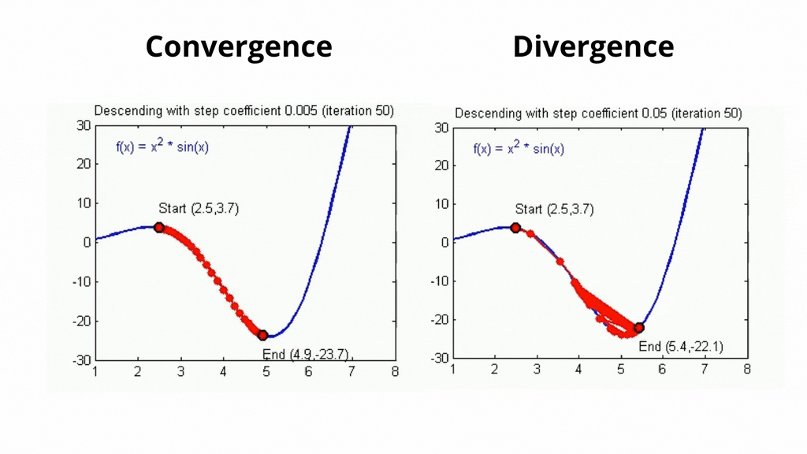

1. sieci głębokie działają wolniej i mają więcej parametrów
2. silniejszy model - większy overfitting
3. wiele **minimów lokalnych**
- model liniowy z wypukłą funkcją kosztu ma tylko jedno **minimum globalne**
  - podążając w kierunku przeciwnym do gradientu w końcu osiągniemy minimum
- sieci neuronowe mają bardzo dużo minimów lokalnych
  - optymalizacja gradientowa nie umie wydostać się z minimum lokalnego
  - prawdopodobnie nigdy nie osiągniemy minimum globalnego
4. problemy z backpropagation w warstwowym modelu
- warstwy uczą się z **różną prędkością**
- np. głębsze warstwy uczą się bardzo powoli, a ostatnie warstwy bardzo szybko próbują rozwiązać problem
  - słabe wyniki
  - nie korzystamy w ogóle z głębokiej struktury
- może być też zupełnie na odwrót
5. **vanishing gradient**
- w algorytmie backpropagation delta musi przejść od najwyższej do najniższej warstwy
- w każdej warstwie jest szansa, że kawałek gradientu zostanie (prawie) wyzerowany
  - np. jeśli funkcja aktywacji saturuje
  - albo dla ujemnych wartości w funkcji ReLU
- im głębiej, tym bardziej efekty te się nawarstwiają
- w najgłębszej warstwie może okazać się, że gradient jest bardzo mały
- mały gradient oznacza, że warstwa ma mały wpływ na output sieci
  - dopiero wyższe warstwy mają istotny wpływ (większy gradient)
6. **exploding gradient**
- w algorytmie backpropagation delta mnożona jest przez macierz wag (przypomnieć sobie wzór)
- jeśli wagi są duże, to delta może zostać zwiększona
- znowu, im głębiej, tym bardziej te efekty mogą się nawarstwiać
- w najgłębszej warstwie gradient może być ogromny
  - całkowity brak stabilności uczenia
  - mała zmiana inputu zupełnie zmieni output sieci

## Różne możliwe rozwiązania

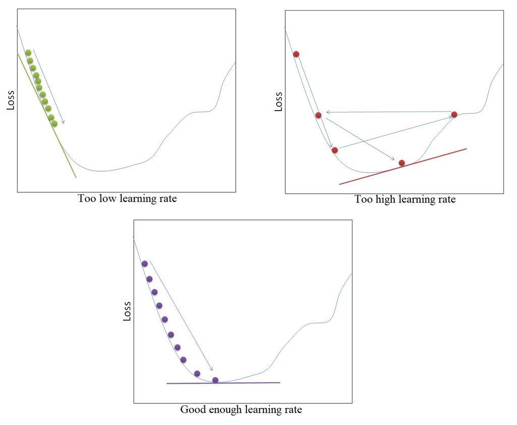

### Znormalizowany input

1. transformacja zbioru treningowego
- trzeba też transformować zbiór testowy!
2. cel - każda współrzędna inputu ma mieć średnią zero i wariancję jeden
- estymujemy średnią i wariancję dla każdej kolumny zbioru treningowego
- odejmujemy średnią, dzielimy przez pierwiastek z wariancji
- zapamiętujemy wektor średnich i wektor wariancji, aby móc transformować przyszłe dane
- **nie powinno się estymować tych parametrów przy użyciu zbioru testowego**
  - zbiór testowy ma symulować dane z przyszłości
  - nie możemy używać go podczas uczenia
  - normalizacja jest częścią procesu uczenia sieci
3. jeszcze lepiej działałaby **dekorelacja cech**
- jeśli dwie kolumny cech są skorelowane, to niosą mniej informacji
- w skrajnym przypadku dwie kolumny cech są identyczne
  - największa korelacja
- dekorelacja wymaga obliczenia i zapamiętania macierzy kowariancji
  - kowariancja każdej pary cech
  - złożoność kwadratowa względem $D$ (obliczenie wariancji ma złożoność liniową)
  - zazwyczaj się tego nie robi

### Inicjalizacja wag sieci

1. inicjalizacja zerami utrudnia uczenie
2. trzeba inicjalizować losowymi wartościami
- trzeba mądrze losować
3. [[Xavier Glorot, Yoshua Bengio, "Understanding the difficulty of training deep feedforward neural networks"]](https://proceedings.mlr.press/v9/glorot10a/glorot10a.pdf)
- kod initializer'a w notebooku na ćwiczeniach
4. pomysł polega na tym, aby (przynajmniej początkowo) wszystkie warstwy dostawały znormalizowany input
- zaawansowane rozszerzenie - *batch normalization*

### Uczenie batchowe

1. liczymy gradient przy pomocy mini-batch'a (np. 64 przykłady treningowe)
2. niedokładne przybliżenie gradientu dla całego zbioru treningowego
- szybsze
- zmniejsza overfitting
  - przez dodatkową losowość model ma problem z zapamiętaniem zbioru treningowego
3. badania nad związkiem rozmiaru mini-batch'a z learning rate
- zmniejszanie learning rate ma podobny efekt jak zwiększanie batch size
- i na odwrót

### Regularyzacja

1. dodajemy do kosztu dodatkowy składnik
2. regularyzacja L2
- suma kwadratów wszystkich parametrów ze wszystkich warstw sieci
- przemnożona przez hiperparametr $\lambda$
3. regularyzacja ma za zadanie zniechęcić sieć do nauczenia się skrajnie dużych wartości dla niektórych parametrów